# CCE_Lab3

Ryan Peckner

7/11/2021

Let’s first read in the forcings data to a dataframe called ‘forcings3’.

```r
library(readxl,quietly = TRUE)
suppressMessages({forcings3 = read_xlsx("CCE - Assignment 3 - Forcings-1.xlsx",skip = 2)})
forcings3 = data.frame(year=as.integer(forcings3[1,][-1]),
                       total.factor.productivity = as.numeric(forcings3[3,][-1]))
head(forcings3)
```

```
##   year total.factor.productivity
## 1 2010                0.02753980
## 2 2011                0.02793993
## 3 2012                0.02832664
## 4 2013                0.02870084
## 5 2014                0.02906350
## 6 2015                0.02941566
```

Let’s write down the Cobb-Douglas production function:

```r
alpha = 0.3

GrossOutput = function(t,total_factor_productivity,capital,population) {
  return(total_factor_productivity[t]*(capital[t]^alpha)*(population[t]^(1-alpha)))
}

NetOutput = function(t,abatement_cost,gross_output) {
  return((1-abatement_cost[t])*gross_output[t])
}
```

Next we have the equation of motion for capital stock. On the face of it, we seem to be in a circular situation, since the net output depends on the capital stock, which depends on the investment rate, which in turn depends again on the net output. So we will untangle this into a slightly different recurrence equation for the capital stock, as follows:
$$\begin{align*}
K_{t} &= (1-\delta)K_{t-1} + I_{t-1} \\
&= (1-\delta)K_{t-1} + sY_{t-1} \\
&= (1-\delta)K_{t-1} + s(1-\Lambda_{t-1})Y_{t-1}^{G} \\
&= (1-\delta)K_{t-1} + s(1-\Lambda_{t-1})A_{t-1}K_{t-1}^{\alpha}P_{t-1}^{1-\alpha}.
\end{align*}$$
This allows us to calculate the capital stock without direct reference to the net output:

```r
library(memoise,quietly=TRUE)

K_0 = 139.65
delta = 0.1
s = 0.22

CapitalStock = memoise(function(t,abatement_cost,total_factor_productivity,population) {
  if (t==1) {
    K_0
  } else {
  K_t_minus_1 = CapitalStock(t-1,abatement_cost,total_factor_productivity,population)
  return((1-delta)*K_t_minus_1 +
  s*(1-abatement_cost[t-1])*total_factor_productivity[t-1]*(K_t_minus_1^alpha)*(population[t-1]^(1-alpha)))}
})
```

Now, let’s copy and paste some of last week’s functions so that we’re completely explicit about linking the Kaya identity and abatement costs to GDP.

```r
forcings2 = read.csv("CCE_Lab2_Outputs.csv",stringsAsFactors = FALSE)

beta_2 = 2.8

KayaEmissions = function(t,population,per_capita_output,energy_intensity,emission_intensity) {
  return(population[t]*per_capita_output[t]*energy_intensity[t]*emission_intensity[t])
}

BAUEmissions = function(t,kaya_emissions,land_use_emissions) {
  return(kaya_emissions[t] + land_use_emissions[t])
}


ControlledEmissions = function(t,bau_emissions,control_rate) {
  return((1-control_rate[t])*bau_emissions[t])
}

AbatementCost = function(t,abatement_coefficient,control_rate) {
  return(abatement_coefficient[t]*((control_rate[t])^beta_2))
}
```

GDP enters the Kaya identity via per capita output; let’s couple this to the calculation above:

```r
KayaEmissionsFromGDP = function(t,population,output,energy_intensity,emission_intensity) {
  per_capita_output = output/population
  return(KayaEmissions(t,population,per_capita_output,energy_intensity,emission_intensity))
}
```

**Question 1:** *In your new model, the cost of abatement in a given year also have an effect on output in subsequent years. You will analyze the strength of this effect for this question.*

In what follows, note that we convert last week’s population numbers from individuals to millions, since this is required for the Cobb-Douglas production function.

```r
forcings3$base.case.control.rate = 0
forcings3$mitigation.policy.control.rate = numeric(nrow(forcings3))
forcings3$mitigation.policy.control.rate[1] = 0.3

#### BAU calculations

forcings3$abatement.cost.bau = 0

forcings3$capital.stock.bau = sapply(1:nrow(forcings3),CapitalStock,
                                  abatement_cost= forcings3$abatement.cost.bau,
                        total_factor_productivity = forcings3$total.factor.productivity,
                        population = forcings2$population*(1e-6))


forcings3$gross.output.bau = sapply(1:nrow(forcings3),
                                    GrossOutput,
                        total_factor_productivity = forcings3$total.factor.productivity,
                        capital = forcings3$capital.stock.bau,
                        population = forcings2$population*(1e-6))

forcings3$net.output.bau = sapply(1:nrow(forcings3),
                                    NetOutput,
                            abatement_cost=forcings3$abatement.cost.bau,
                            gross_output=forcings3$gross.output.bau)

#### Mitigation policy calculations

forcings3$abatement.cost.mitigation.policy =
                              sapply(1:nrow(forcings3),
                            AbatementCost,
                    abatement_coefficient = forcings2$abatement.cost.function.coefficient,
                    control_rate = forcings3$mitigation.policy.control.rate)

forcings3$capital.stock.mitigation.policy = sapply(1:nrow(forcings3),CapitalStock,
                                  abatement_cost= forcings3$abatement.cost.mitigation.policy,
                        total_factor_productivity = forcings3$total.factor.productivity,
                        population = forcings2$population*(1e-6))


forcings3$gross.output.mitigation.policy = sapply(1:nrow(forcings3),
                                    GrossOutput,
                        total_factor_productivity = forcings3$total.factor.productivity,
                        capital = forcings3$capital.stock.mitigation.policy,
                        population = forcings2$population*(1e-6))

forcings3$net.output.mitigation.policy = sapply(1:nrow(forcings3),
                                    NetOutput,
                            abatement_cost=forcings3$abatement.cost.mitigation.policy,
                            gross_output=forcings3$gross.output.mitigation.policy)

head(forcings3)
```

```
##   year total.factor.productivity base.case.control.rate
## 1 2010                0.02753980                      0
## 2 2011                0.02793993                      0
## 3 2012                0.02832664                      0
## 4 2013                0.02870084                      0
## 5 2014                0.02906350                      0
## 6 2015                0.02941566                      0
##   mitigation.policy.control.rate abatement.cost.bau capital.stock.bau
## 1                            0.3                  0          139.6500
## 2                            0.0                  0          138.6595
## 3                            0.0                  0          138.0463
## 4                            0.0                  0          137.7784
## 5                            0.0                  0          137.8272
## 6                            0.0                  0          138.1670
##   gross.output.bau net.output.bau abatement.cost.mitigation.policy
```

[output cut: 20 more lines]

We can now find the year when the difference between net output in the two models falls to less than 1 billion dollars per year, using the fact that net output is measured in trillions of dollars:

```r
year_index = which(abs(forcings3$net.output.bau - forcings3$net.output.mitigation.policy) < 1e-3)[1]
print(forcings3$year[year_index])
```

```
## [1] 2031
```

And finally we can plot the differences between net outputs in the base case vs mitigation policy models:

```r
library(ggplot2,quietly = T)
hrbrthemes::import_roboto_condensed()

library(hrbrthemes, quietly = T)
d <- read.csv(extrafont:::fonttable_file(), stringsAsFactors = FALSE)
d[grepl("Light", d$FontName),]$FamilyName <- font_rc_light
write.csv(d,extrafont:::fonttable_file(), row.names = FALSE)
extrafont::loadfonts()
```

```
## Registering font with R using pdfFonts(): Roboto Condensed
```

```
## Registering font with R using pdfFonts(): Roboto Condensed Light
```

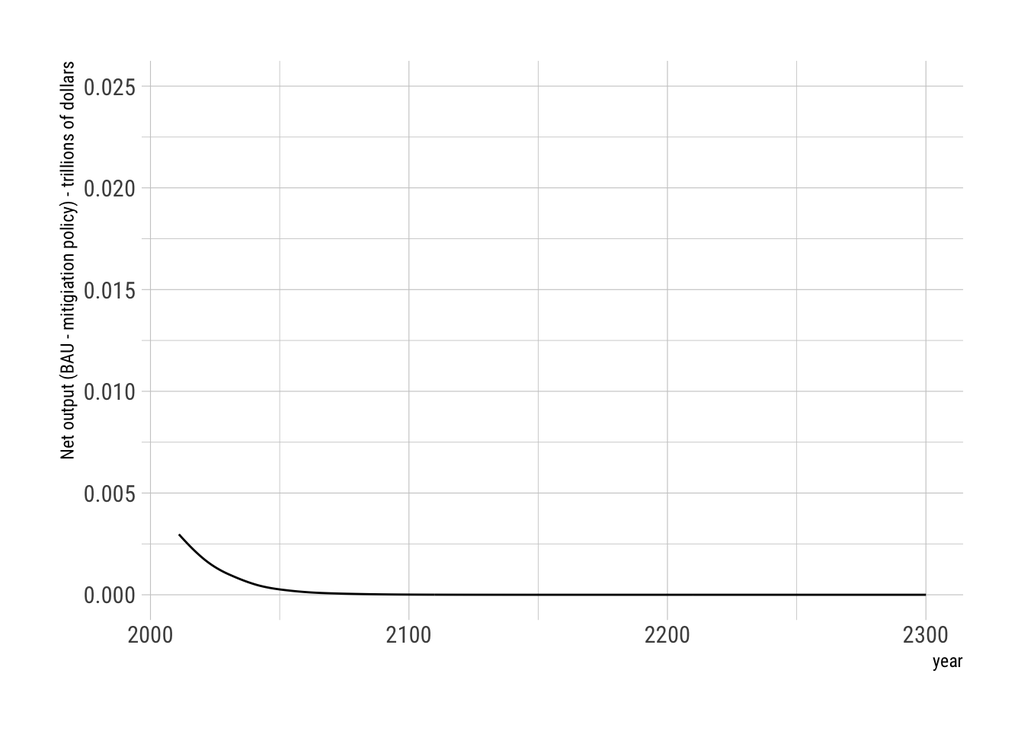

```r
library(gcookbook,quietly = T)

ggplot(forcings3,aes(x=year,y=net.output.bau - net.output.mitigation.policy)) + geom_line() +
  theme_ipsum_rc() + xlim(2011,2300) + ylab("Net output (BAU - mitigiation policy) - trillions of dollars") + ylim(0,0.025)
```